# Graphique pour ROEL

exemple à reproduire:

[figure not shown]

- scan du directoire (fonction custom os.walk)
- import d'un fichier dans un dataframe
- filtre par **saison** du dataframe en fonction du fichier equinoxes.csv ?
- trouver un code qui se raproche
- générer le premier graphique HR/TMP
- statistique
- intération

# Import des dépendances

```python
import os
from time import perf_counter
import pandas
from colorama import Fore
import seaborn as sns
import matplotlib.pyplot as plt
import datetime
# from tqdm.notebook import tqdm
```

```python
def moon_walk(path_to_dir, verbose=True):

    if verbose == True:
        print(f"Start Scan in '{path_to_dir}':")

    tps_scan_start = perf_counter()

    liste_fichiers_csv = []
    for root, dirs, files in os.walk(path_to_dir, topdown=False):
        for name in files:
            if ".csv" in name:
                temporary_string = os.path.join(root, name)
                temporary_string = temporary_string.replace("\\", "/")
                liste_fichiers_csv.append(temporary_string)

    tps_scan_stop = perf_counter()
    tps_scan = round(tps_scan_stop - tps_scan_start, 2)

    if verbose == True:
        print(f"MJ a trouvé {len(liste_fichiers_csv)} fichier(s) en {tps_scan} secondes\n\n")

    return liste_fichiers_csv
```

```python
working_path=os.getcwd().replace("\\", "/")+"/CSV/"
liste_fichiers_csv = moon_walk(working_path)
print(liste_fichiers_csv[:5])
```

```
Start Scan in 'c:/Users/Mathi/Desktop/graphique/CSV/':
MJ a trouvé 29 fichier(s) en 0.0 secondes


['c:/Users/Mathi/Desktop/graphique/CSV/ELOCKET_Brugge_Buiten_HUM_20180107_20211207.csv', 'c:/Users/Mathi/Desktop/graphique/CSV/ELOCKET_Brugge_Bureau_HUM_20180107_20211207.csv', 'c:/Users/Mathi/Desktop/graphique/CSV/ELOCKET_Brugge_Keuken_HUM_20180107_20211207.csv', 'c:/Users/Mathi/Desktop/graphique/C…
```

# import d'un fichier dans un df

On va travailler sur le bureau

```python
df_file = pandas.read_csv(liste_fichiers_csv[1],sep=";")
df_file=df_file.drop("RawData", axis=1)
df_file.Date = pandas.to_datetime(df_file.Date)
df_file.rename(columns={"Date": "DATE"}, inplace=True)
df_file = df_file.sort_values(by=["DATE"])
df_file.set_index("DATE", inplace= True)
# df_file=df_file.drop_duplicates()
df_file = df_file[~df_file.index.duplicated()]
```

```python
from datetime import date

today = date.today()
print("Today's date:", today)
```

```
Today's date: 2021-10-15
```

```python
df_file
```

| DATE | SITE | ROOM | TYPE | HUMIDITY | TEMPERATURE |
| --- | --- | --- | --- | --- | --- |
| 2018-01-07 00:00:14 | Brugge | Bureau | HUM | 44.20 | 19.15 |
| 2018-01-07 00:15:17 | Brugge | Bureau | HUM | 44.14 | 19.00 |
| 2018-01-07 00:30:18 | Brugge | Bureau | HUM | 44.12 | 18.86 |
| 2018-01-07 00:45:20 | Brugge | Bureau | HUM | 44.10 | 18.71 |
| 2018-01-07 01:00:21 | Brugge | Bureau | HUM | 44.15 | 18.57 |
| ... | ... | ... | ... | ... | ... |
| 2021-12-07 22:53:00 | Brugge | Bureau | HUM | 70.68 | 21.76 |
| 2021-12-07 23:08:00 | Brugge | Bureau | HUM | 70.78 | 21.80 |
| 2021-12-07 23:23:00 | Brugge | Bureau | HUM | 70.87 | 21.83 |
| 2021-12-07 23:38:00 | Brugge | Bureau | HUM | 70.95 | 21.84 |
| 2021-12-07 23:53:00 | Brugge | Bureau | HUM | 71.01 | 21.85 |

102955 rows × 5 columns

```python
df_file.dtypes
```

```
SITE            object
ROOM            object
TYPE            object
HUMIDITY       float64
TEMPERATURE    float64
dtype: object
```

# filtre par saisons

fichier *equinox.csv*

Solstices et équinoxes en 2021

| Jour charnière | Date |
| --- | --- |
| Équinoxe de mars | samedi 20 mars 2021 à 10h37 |
| Solstice de juin | lundi 21 juin 2021 à 05h32 |
| Équinoxe de septembre | mercredi 22 septembre 2021 à 21h21 |
| Solstice de décembre | mardi 21 décembre 2021 à 16h59 |

Ci-dessous les dates des saisons de l'année, en commençant par la saison en cours :

>

> L'automne actuel se terminera le lundi 20 décembre 2021

> L'hiver aura lieu du mardi 21 décembre au samedi 19 mars 2022

> Le printemps aura lieu du dimanche 20 mars au lundi 20 juin 2022

> L'été aura lieu du mardi 21 juin au jeudi 22 septembre 2022

[lien vers la sources](https://icalendrier.fr/saisons)

```python
"_"*50+"\n"+"-"
```

```
'__________________________________________________\n-'
```

```python
cover_range_df_file = df_file.index.max() - df_file.index.min()
print(f"The data cover an range of {Fore.MAGENTA}{cover_range_df_file}{Fore.RESET}")
print(f"From {Fore.CYAN}{df_file.index.min()}{Fore.RESET} to {Fore.CYAN}{df_file.index.max()}{Fore.RESET}")
```

```
The data cover an range of 1430 days 23:52:46
From 2018-01-07 00:00:14 to 2021-12-07 23:53:00
```

```python
liste_saison=[
    ("Winter", "2017-12-21 00:00:00", "2018-03-19 23:59:59"),
    ("Lente" , "2018-03-20 00:00:00", "2018-06-20 23:59:59"),
    ("Zomer" , "2018-06-21 00:00:00", "2018-09-20 23:59:59"),
    ("Herfst", "2018-09-21 00:00:00", "2018-12-20 23:59:59"),
    ("Winter", "2018-12-21 00:00:00", "2019-03-19 23:59:59"),
    ("Lente" , "2019-03-20 00:00:00", "2019-06-20 23:59:59"),
    ("Zomer" , "2019-06-21 00:00:00", "2019-09-20 23:59:59"),
    ("Herfst", "2019-09-21 00:00:00", "2019-12-20 23:59:59"),
    ("Winter", "2019-12-21 00:00:00", "2020-03-19 23:59:59"),
    ("Lente" , "2020-03-20 00:00:00", "2020-06-19 23:59:59"),
    ("Zomer" , "2020-06-20 00:00:00", "2020-09-21 23:59:59"),
    ("Herfst", "2020-09-22 00:00:00", "2020-12-20 23:59:59"),
    ("Winter", "2020-12-21 00:00:00", "2021-03-19 23:59:59"),
    ("Lente" , "2021-03-20 00:00:00", "2021-06-20 23:59:59"),
    ("Zomer" , "2021-06-21 00:00:00", "2021-09-20 23:59:59"),
    ("Herfst", "2021-09-21 00:00:00", "2021-12-20 23:59:59"),
    ("Winter", "2021-12-21 00:00:00", "2022-03-19 23:59:59")
]
```

```python
season = liste_saison[0][0]
start  = liste_saison[0][1]
end    = liste_saison[0][2]
print(f"la saison {Fore.CYAN}{season}{Fore.RESET} commence le {Fore.CYAN}{start}{Fore.RESET} et fini le {Fore.CYAN}{end}{Fore.RESET}.")

# filtre_summer_2018 = (df_file.index>=start) & (df_file.index<=end)
# df_file[filtre_summer_2018]
```

```
la saison Winter commence le 2017-12-21 00:00:00 et fini le 2018-03-19 23:59:59.
```

```python
for _ in range(len(liste_saison)):

    season = liste_saison[_][0]
    start  = liste_saison[_][1]
    end    = liste_saison[_][2]

    print(f"la saison {Fore.CYAN}{season}{Fore.RESET} commence le {Fore.CYAN}{start}{Fore.RESET} et fini le {Fore.CYAN}{end}{Fore.RESET}.")

    # filtre_summer_2018 = (df_file.index>=start) & (df_file.index<=end)
    # df_file[filtre_summer_2018].shapes
```

```
la saison Winter commence le 2017-12-21 00:00:00 et fini le 2018-03-19 23:59:59.
la saison Lente commence le 2018-03-20 00:00:00 et fini le 2018-06-20 23:59:59.
la saison Zomer commence le 2018-06-21 00:00:00 et fini le 2018-09-20 23:59:59.
la saison Herfst commence le 2018-09-21 00:00:00 et fini le 2018-12-20 23:59:59.
la saison Winter commence le 2018-12-21 00:00:00 et fini le 2019-03-19 23:59:59.
la saison Lente commence le 2019-03-20 00:00:00 et fini le 2019-06-20 23:59:59.
la saison Zomer commence le 2019-06-21 00:00:00 et fini le 2019-09-20 23:59:59.
la saison Herfst commence le 2019-09-21 00:00:00 et fini le 2019-12-20 23:59:59.
la saison Winter commence le 2019-12-21 00:00:00 et fini le 2020-03-19 23:59:59.
la saison Lente commence le 2020-03-20 00:00:00 et fini le 2020-06-19 23:59:59.
la saison Zomer commence le 2020-06-20 00:00:00 et fini le 2020-09-21 23:59:59.
la saison Herfst commence le 2020-09-22 00:00:00 et fini le 2020-12-20 23:59:59.
la saison Winter commence le 2020-12-21 00:00:00 et fini le 2021-03-19 23:59:59.
la saison Lente commence le 2021-03-20 00:00:00 et fini le 2021-06-20 23:59:59.
la saison Zomer commence le 2021-06-21 00:00:00 et fini le 2021-09-20 23:59:59.
la saison Herfst commence le 2021-09-21 00:00:00 et fini le 2021-12-20 23:59:59.
la saison Winter commence le 2021-12-21 00:00:00 et fini le 2022-03-19 23:59:59.
```

## Création d'une colonne saeson

```python
season = liste_saison[0][0]
start  = liste_saison[0][1]
end    = liste_saison[0][2]
```

```python
start
```

```
'2017-12-21 00:00:00'
```

```python
(df_file.index>=start) & (df_file.index<=end)
```

```
array([ True,  True,  True, ..., False, False, False])
```

```python
df_file.index>=start
```

```
array([ True,  True,  True, ...,  True,  True,  True])
```

```python
liste_datum = df_file.index.to_list()
```

```python
liste_datum[0]
```

```
Timestamp('2018-01-07 00:00:14')
```

```python
liste_saison[0][1]
```

```
'2017-12-21 00:00:00'
```

```python
datetime.datetime.strptime(liste_saison[0][1], "%Y-%m-%d %H:%M:%S")
```

```
datetime.datetime(2017, 12, 21, 0, 0)
```

```python
liste_datum[0]>datetime.datetime.strptime(liste_saison[0][1], "%Y-%m-%d %H:%M:%S")
```

```
True
```

```python
len(liste_datum)
```

```
102955
```

```python
liste_column_season =[]

for datum in liste_datum:
    # print(datum, end='\t')

    for _ in range(len(liste_saison)):

        season = liste_saison[_][0]
        start  = liste_saison[_][1]
        end    = liste_saison[_][2]

        start  = datetime.datetime.strptime(start, "%Y-%m-%d %H:%M:%S")
        end    = datetime.datetime.strptime(end, "%Y-%m-%d %H:%M:%S")


        if ((datum >= start) & (datum <= end)):
            # print(season,end="\n")
            liste_column_season.append(season)
        # else:
        #     print("false")


        # print("\n")
        # print(f"la saison {Fore.CYAN}{season}{Fore.RESET} commence le {Fore.CYAN}{start}{Fore.RESET} et fini le {Fore.CYAN}{end}{Fore.RESET}.")
    # print("\n")
```

```python
len(liste_column_season)
```

```
102955
```

```python
df_file["SEASONS"]=liste_column_season
```

```python
df_file
```

| DATE | SITE | ROOM | TYPE | HUMIDITY | TEMPERATURE | SEASONS |
| --- | --- | --- | --- | --- | --- | --- |
| 2018-01-07 00:00:14 | Brugge | Bureau | HUM | 44.20 | 19.15 | Winter |
| 2018-01-07 00:15:17 | Brugge | Bureau | HUM | 44.14 | 19.00 | Winter |
| 2018-01-07 00:30:18 | Brugge | Bureau | HUM | 44.12 | 18.86 | Winter |
| 2018-01-07 00:45:20 | Brugge | Bureau | HUM | 44.10 | 18.71 | Winter |
| 2018-01-07 01:00:21 | Brugge | Bureau | HUM | 44.15 | 18.57 | Winter |
| ... | ... | ... | ... | ... | ... | ... |
| 2021-12-07 22:53:00 | Brugge | Bureau | HUM | 70.68 | 21.76 | Herfst |
| 2021-12-07 23:08:00 | Brugge | Bureau | HUM | 70.78 | 21.80 | Herfst |
| 2021-12-07 23:23:00 | Brugge | Bureau | HUM | 70.87 | 21.83 | Herfst |
| 2021-12-07 23:38:00 | Brugge | Bureau | HUM | 70.95 | 21.84 | Herfst |
| 2021-12-07 23:53:00 | Brugge | Bureau | HUM | 71.01 | 21.85 | Herfst |

102955 rows × 6 columns

```python
df_file.SEASONS.unique()
```

```
array(['Winter', 'Lente', 'Zomer', 'Herfst'], dtype=object)
```

# code exemples

seaborn.relplot

seaborn.relplot(*, x=None, y=None, hue=None, size=None, style=None, data=None, row=None, col=None, col_wrap=None, row_order=None, col_order=None, palette=None, hue_order=None, hue_norm=None, sizes=None, size_order=None, size_norm=None, markers=None, dashes=None, style_order=None, legend='auto', kind='scatter', height=5, aspect=1, facet_kws=None, units=None, **kwargs)

Figure-level interface for drawing relational plots onto a FacetGrid.

This function provides access to several different axes-level functions that show the relationship between two variables with semantic mappings of subsets. The kind parameter selects the underlying axes-level function to use:

```
scatterplot() (with kind="scatter"; the default)

lineplot() (with kind="line")
```

Extra keyword arguments are passed to the underlying function, so you should refer to the documentation for each to see kind-specific options.

The relationship between x and y can be shown for different subsets of the data using the hue, size, and style parameters. These parameters control what visual semantics are used to identify the different subsets. It is possible to show up to three dimensions independently by using all three semantic types, but this style of plot can be hard to interpret and is often ineffective. Using redundant semantics (i.e. both hue and style for the same variable) can be helpful for making graphics more accessible.

See the tutorial for more information.

After plotting, the FacetGrid with the plot is returned and can be used directly to tweak supporting plot details or add other layers.

Note that, unlike when using the underlying plotting functions directly, data must be passed in a long-form DataFrame with variables specified by passing strings to x, y, and other parameters.

```
-python
sns.relplot(data=tips, x="total_bill", y="tip", hue="day")
```

[figure not shown]

[lien vers la source](https://seaborn.pydata.org/generated/seaborn.relplot.html)

```python
df_file
```

| DATE | SITE | ROOM | TYPE | HUMIDITY | TEMPERATURE | SEASONS |
| --- | --- | --- | --- | --- | --- | --- |
| 2018-01-07 00:00:14 | Brugge | Bureau | HUM | 44.20 | 19.15 | Winter |
| 2018-01-07 00:15:17 | Brugge | Bureau | HUM | 44.14 | 19.00 | Winter |
| 2018-01-07 00:30:18 | Brugge | Bureau | HUM | 44.12 | 18.86 | Winter |
| 2018-01-07 00:45:20 | Brugge | Bureau | HUM | 44.10 | 18.71 | Winter |
| 2018-01-07 01:00:21 | Brugge | Bureau | HUM | 44.15 | 18.57 | Winter |
| ... | ... | ... | ... | ... | ... | ... |
| 2021-12-07 22:53:00 | Brugge | Bureau | HUM | 70.68 | 21.76 | Herfst |
| 2021-12-07 23:08:00 | Brugge | Bureau | HUM | 70.78 | 21.80 | Herfst |
| 2021-12-07 23:23:00 | Brugge | Bureau | HUM | 70.87 | 21.83 | Herfst |
| 2021-12-07 23:38:00 | Brugge | Bureau | HUM | 70.95 | 21.84 | Herfst |
| 2021-12-07 23:53:00 | Brugge | Bureau | HUM | 71.01 | 21.85 | Herfst |

102955 rows × 6 columns

```python
name_of_df_file = f"{df_file.SITE.unique()[0]}-{df_file.ROOM.unique()[0]}"
name_of_df_file
```

```
'Brugge-Bureau'
```

```python
# Mise en place du graphique
sns.set(style="darkgrid")
sns.set()
figure, ax = plt.subplots(figsize=(7, 8))

ax = sns.relplot(data=df_file, x="TEMPERATURE", y="HUMIDITY", hue="SEASONS", marker=",", s=2)

plt.xticks([0, 3, 6, 9, 12, 15, 18, 21, 24, 27, 30])
plt.yticks([10, 20, 30, 40, 50, 60, 70, 80, 90, 100])
plt.xlim(0, 30)
plt.ylim(0, 100)

plt.ylabel("Relatieve vochtigheid [%]")
plt.xlabel("Temperatuure [°C]")
plt.title(f"{name_of_df_file}")

plt.savefig(f"{name_of_df_file}_bivariate.png")
plt.close("all")
```

[figure not shown]

```python
sns.set(style="darkgrid")

figure, ax = plt.subplots(figsize=(7, 8))

ax = sns.relplot(data=df_file, x="TEMPERATURE", y="HUMIDITY", hue="SEASONS", col="SEASONS", marker=",", s=2)

plt.xticks([0, 3, 6, 9, 12, 15, 18, 21, 24, 27, 30])
plt.yticks([10, 20, 30, 40, 50, 60, 70, 80, 90, 100])
plt.xlim(0, 30)
plt.ylim(0, 100)

ax.set_axis_labels(x_var="Temperatuure [°C]", y_var="Relatieve vochtigheid [%")

plt.savefig(f"{name_of_df_file}_bivariate_per_seasons.png")
plt.close("all")
```

[figure not shown]

# création des statistiques

```python
for _ in range(len(liste_saison[:2])):

    season = liste_saison[_][0]
    start  = liste_saison[_][1]
    end    = liste_saison[_][2]

    print(f"la saison {Fore.CYAN}{season}{Fore.RESET} commence le {Fore.CYAN}{start}{Fore.RESET} et fini le {Fore.CYAN}{end}{Fore.RESET}.")

    start  = datetime.datetime.strptime(start, "%Y-%m-%d %H:%M:%S")
    end    = datetime.datetime.strptime(end, "%Y-%m-%d %H:%M:%S")

    filtre_seasons = (df_file.index>=start) & (df_file.index<=end)
    print(df_file[filtre_seasons].shape)
    print(f'[Data cover] Range: {end-start} | Start: {start} | End: {end}')

    print('')
```

```
la saison Winter commence le 2017-12-21 00:00:00 et fini le 2018-03-19 23:59:59.
(4425, 6)
[Data cover] Range: 88 days, 23:59:59 | Start: 2017-12-21 00:00:00 | End: 2018-03-19 23:59:59

la saison Lente commence le 2018-03-20 00:00:00 et fini le 2018-06-20 23:59:59.
(8779, 6)
[Data cover] Range: 92 days, 23:59:59 | Start: 2018-03-20 00:00:00 | End: 2018-06-20 23:59:59
```

```python
df_file.shape
```

```
(102955, 6)
```

```python
isExist = os.path.exists(f"OUTPUT\{name_of_df_file}")
# isExist = os.path.exists(f"OUTPUT\{df_file.SITE.unique()[0]}_{df_file.ROOM.unique()[0]}")
if not isExist:
    # Create a new directory because it does not exist
    os.makedirs(f"OUTPUT\{name_of_df_file}")
    # wlog(f"The directory {name_of_df_file} is created!")
```

```python
# Calcul des statistique descriptive du jeux de données 'Humidité'
statistique =""
describe_HUM = df_file.HUMIDITY.describe()
liste_index = describe_HUM.index.tolist()
liste_values = describe_HUM.values.tolist()
statistique += "\n[Humidity] "
for cpt_describe in range(len(liste_index)):
    if cpt_describe == 0:
        statistique += f"{str(liste_index[cpt_describe])}: {str(int(liste_values[cpt_describe]))} Values | "
    else:
        statistique += f"{str(liste_index[cpt_describe])}: {str(round(liste_values[cpt_describe], 0))}% | "

print(statistique)
```

```
[Humidity] count: 102955 Values | mean: 55.0% | std: 9.0% | min: 20.0% | 25%: 49.0% | 50%: 55.0% | 75%: 62.0% | max: 78.0% |
```

```python
# Calcul des statistique descriptive du jeux de données 'Termperature'
statistique =""
describe_TMP = df_file.TEMPERATURE.describe()
liste_index = describe_TMP.index.tolist()
liste_values = describe_TMP.values.tolist()
statistique += "\n[Temperature] "
for cpt_describe in range(len(liste_index)):
    if cpt_describe == 0:
        statistique += f"{str(liste_index[cpt_describe])}: {str(int(liste_values[cpt_describe]))} Values | "
    else:
        statistique += f"{str(liste_index[cpt_describe])}: {str(round(liste_values[cpt_describe], 2))}°C | "

print(statistique)
```

```
[Temperature] count: 102955 Values | mean: 19.46°C | std: 2.97°C | min: 7.49°C | 25%: 17.47°C | 50%: 19.2°C | 75%: 21.41°C | max: 30.09°C |
```

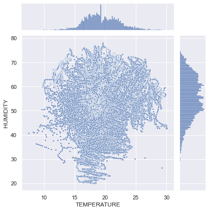

```python
sns.jointplot(data=df_file, x="TEMPERATURE", y="HUMIDITY", marker=".")
```

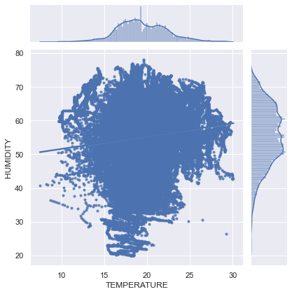

```python
sns.jointplot(data=df_file, x="TEMPERATURE", y="HUMIDITY",  kind="reg", marker=".")
# sns.histplot(data=df_file, x="HUMIDITY")
```

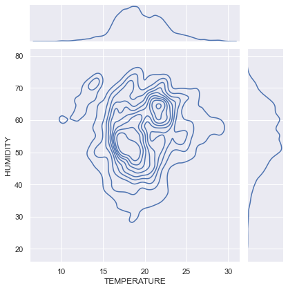

```python
sns.jointplot(data=df_file, x="TEMPERATURE", y="HUMIDITY",  kind="kde")
```

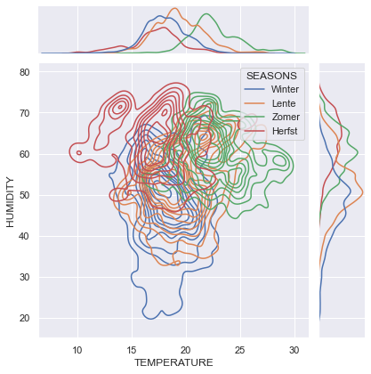

```python
sns.jointplot(data=df_file, x="TEMPERATURE", y="HUMIDITY", hue="SEASONS",  kind="kde")
```

```python
class Open_File:
    def __init__(self, filename, mode):
        self.filename = filename
        self.mode = mode

    def __enter__(self):
        self.file = open(self.filename, self.mode)
        return self.file

    def __exit__(self, exc_type, exc_val, traceback):
        self.file.close()
```

```python
# creation d'un chaine vide pour récupérer les stats incrémentativement
statistique = ""

# cover range du dataset
x_start = df_file.index.min()
x_end = df_file.index.max()
statistique += (
    f"\n[Data cover Range]\n{x_end-x_start}\nStart: {x_start} \n End: {x_end}\n"
)

# Calcul des statistique descriptive du jeux de données 'Humidité'
describe_HUM = df_file.HUMIDITY.describe()
liste_index = describe_HUM.index.tolist()
liste_values = describe_HUM.values.tolist()
statistique += "\n[Relatieve vochtigheid]\n"
for cpt_describe in range(len(liste_index)):
    if cpt_describe == 0:
        statistique += f"{str(liste_index[cpt_describe])}: {str(int(liste_values[cpt_describe]))} Values \n "
    else:
        statistique += f"{str(liste_index[cpt_describe])}: {str(round(liste_values[cpt_describe], 0))}% \n "

# Calcul des statistique descriptive du jeux de données 'Termperature'
describe_TMP = df_file.TEMPERATURE.describe()
liste_index = describe_TMP.index.tolist()
liste_values = describe_TMP.values.tolist()
statistique += "\n[Temperatuure]\n"
for cpt_describe in range(len(liste_index)):
    if cpt_describe == 0:
        statistique += f"{str(liste_index[cpt_describe])}: {str(int(liste_values[cpt_describe]))} Values \n "
    else:
        statistique += f"{str(liste_index[cpt_describe])}: {str(round(liste_values[cpt_describe], 2))} deg C \n "


# Mise en place du graphique
sns.set(style="darkgrid")
sns.set()
figure, graph = plt.subplots(figsize=(7, 8))

graph = sns.relplot(data=df_file, x="TEMPERATURE", y="HUMIDITY", hue="SEASONS", marker=",", s=2, legend="auto")

plt.xticks([0, 3, 6, 9, 12, 15, 18, 21, 24, 27, 30])
plt.yticks([10, 20, 30, 40, 50, 60, 70, 80, 90, 100])
plt.xlim(0, 30)
plt.ylim(0, 100)

plt.ylabel("Relatieve vochtigheid [%]")
plt.xlabel("Temperatuure [°C]")
plt.title(f"{name_of_df_file}")

plt.savefig(f"{name_of_df_file}_bivariate_stats.png", bbox_inches="tight")
plt.close("all")

print(statistique)
```

[output not shown]

```python
statistique
```

```
'\n[Data cover Range]\n1430 days 23:52:46\nStart: 2018-01-07 00:00:14 \n End: 2021-12-07 23:53:00\n\n[Relatieve vochtigheid]\ncount: 102955 Values \n mean: 55.0% \n std: 9.0% \n min: 20.0% \n 25%: 49.0% \n 50%: 55.0% \n 75%: 62.0% \n max: 78.0% \n \n[Temperatuure]\ncount: 102955 Values \n mean: 19.4…
```

```python
with Open_File(f"{name_of_df_file}_overall_stats.txt", "a") as f:
    f.write(statistique)
```